# Predicting Breast Cancer Malignancy Using Data Mining Algorithms

Lin_Deng

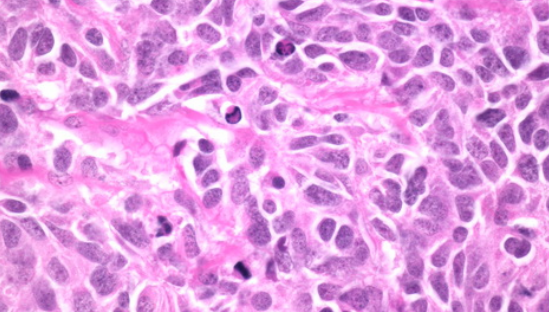

```r
library(tidyverse)
library(ISLR)
library(rpart)
library(partykit)
library(randomForest)
library(gbm)
library(leaps)
library(MASS)
library(class)
library(boot)
library(rpart.plot)
```

# I. Introduction & Background

Today, in the USA, about one in eight women has a risk of suffering from breast cancer over their life time. Hence we need to dig out the relevant variables that can predict malignant tumor.

This data can be found on [UC Irvine Machine Learning Repository](http://archive.ics.uci.edu/ml/datasets/Breast+Cancer+Wisconsin+%28Diagnostic%29).

This dataset contains:

Attribute Information:

- ID number
- Diagnosis (M = malignant, B = benign)

Ten real-valued features are computed for each cell nucleus:

- radius (mean of distances from center to points on the perimeter)
- texture (standard deviation of gray-scale values)
- perimeter
- area
- smoothness (local variation in radius lengths)
- compactness (perimeter^2 / area - 1.0)
- concavity (severity of concave portions of the contour)
- concave points (number of concave portions of the contour)
- symmetry
- fractal dimension (“coastline approximation” - 1)

# II. Tidy Data

## 2.1. Import data

```r
bc <- read.csv("F:/2018_spring_semester_master/IE_5561_Data Driven Decision/Assignment/Project_1/breast-cancer-wisconsin-data/data.csv")
str(bc)
```

```
## 'data.frame':    569 obs. of  33 variables:
##  $ id                     : int  842302 842517 84300903 84348301 84358402 843786 844359 84458202 844981 84501001 ...
##  $ diagnosis              : Factor w/ 2 levels "B","M": 2 2 2 2 2 2 2 2 2 2 ...
##  $ radius_mean            : num  18 20.6 19.7 11.4 20.3 ...
##  $ texture_mean           : num  10.4 17.8 21.2 20.4 14.3 ...
##  $ perimeter_mean         : num  122.8 132.9 130 77.6 135.1 ...
##  $ area_mean              : num  1001 1326 1203 386 1297 ...
##  $ smoothness_mean        : num  0.1184 0.0847 0.1096 0.1425 0.1003 ...
##  $ compactness_mean       : num  0.2776 0.0786 0.1599 0.2839 0.1328 ...
##  $ concavity_mean         : num  0.3001 0.0869 0.1974 0.2414 0.198 ...
##  $ concave.points_mean    : num  0.1471 0.0702 0.1279 0.1052 0.1043 ...
##  $ symmetry_mean          : num  0.242 0.181 0.207 0.26 0.181 ...
##  $ fractal_dimension_mean : num  0.0787 0.0567 0.06 0.0974 0.0588 ...
##  $ radius_se              : num  1.095 0.543 0.746 0.496 0.757 ...
##  $ texture_se             : num  0.905 0.734 0.787 1.156 0.781 ...
```

[output cut: 19 more lines]

## 2.2. Tidy data

```r
bc$id <- NULL # remove unrelated variable
bc <- Filter(function(x) (length(unique(x)) > 1), bc) # remove variable only contains NA data
str(bc)
```

```
## 'data.frame':    569 obs. of  31 variables:
##  $ diagnosis              : Factor w/ 2 levels "B","M": 2 2 2 2 2 2 2 2 2 2 ...
##  $ radius_mean            : num  18 20.6 19.7 11.4 20.3 ...
##  $ texture_mean           : num  10.4 17.8 21.2 20.4 14.3 ...
##  $ perimeter_mean         : num  122.8 132.9 130 77.6 135.1 ...
##  $ area_mean              : num  1001 1326 1203 386 1297 ...
##  $ smoothness_mean        : num  0.1184 0.0847 0.1096 0.1425 0.1003 ...
##  $ compactness_mean       : num  0.2776 0.0786 0.1599 0.2839 0.1328 ...
##  $ concavity_mean         : num  0.3001 0.0869 0.1974 0.2414 0.198 ...
##  $ concave.points_mean    : num  0.1471 0.0702 0.1279 0.1052 0.1043 ...
##  $ symmetry_mean          : num  0.242 0.181 0.207 0.26 0.181 ...
##  $ fractal_dimension_mean : num  0.0787 0.0567 0.06 0.0974 0.0588 ...
##  $ radius_se              : num  1.095 0.543 0.746 0.496 0.757 ...
##  $ texture_se             : num  0.905 0.734 0.787 1.156 0.781 ...
##  $ perimeter_se           : num  8.59 3.4 4.58 3.44 5.44 ...
```

[output cut: 17 more lines]

```r
table(bc$diagnosis) #benign: 357, #malignant:212
```

```
##
##   B   M
## 357 212
```

# III. Description & Basic Visualization

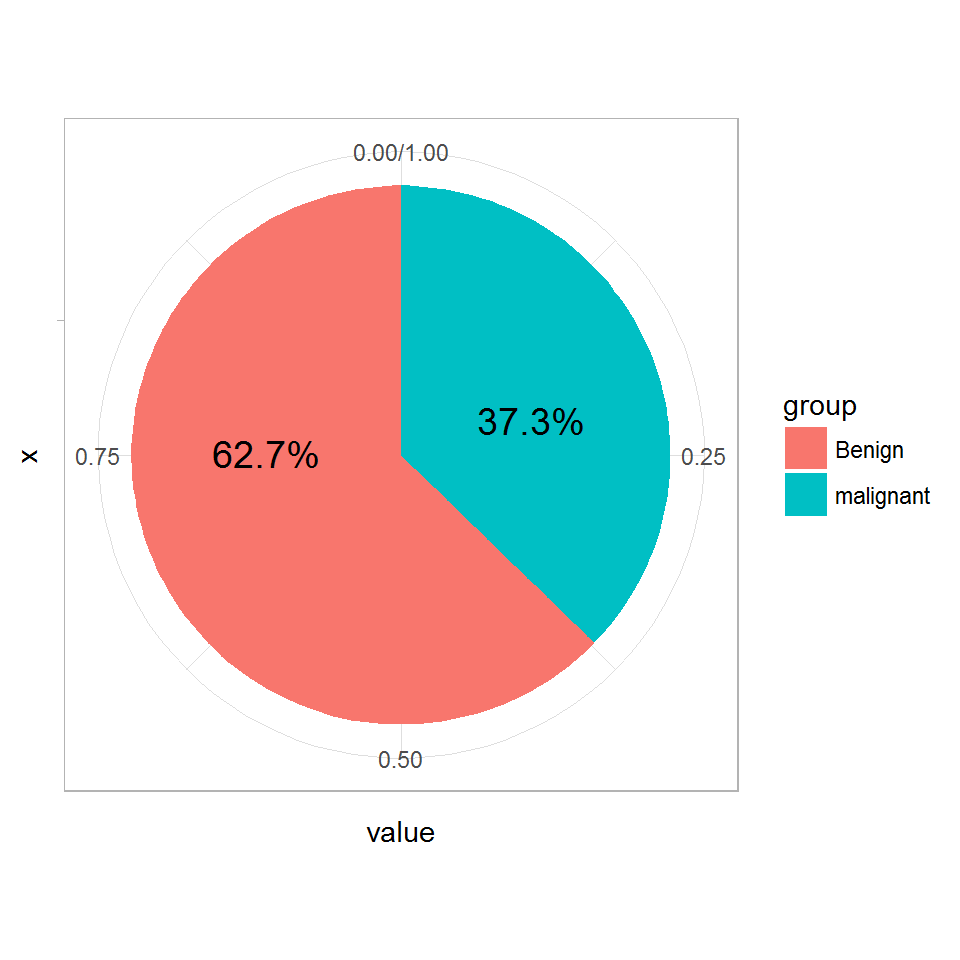

```r
library(scales)

pie <- data.frame(group = c("Benign", "malignant"),
                  value = c(357/569, 212/569))

ggplot(pie, aes(x="", y = value, fill = group)) +
  geom_bar(width = 1, stat = "identity") +
  coord_polar("y", start = 0) +
  geom_text(aes(y = value/3 + c(0, cumsum(value)[-length(value)]), label = c(percent(0.3726), percent(0.6274))), size = 5) + theme_light()
```

In 569 cases, 62.7% are Benign tumor, 37.3% are malignant tumor.

Here are desity plots of each variables.

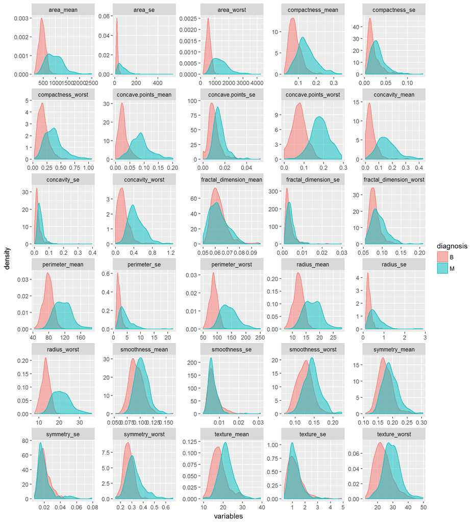

```r
gather(bc, x, variables, radius_mean:fractal_dimension_worst) %>%
  ggplot(aes(x =variables, color = diagnosis, fill = diagnosis)) + geom_density(aes(color = diagnosis, fill = diagnosis), alpha = 0.5) +
  facet_wrap(~x, scales = "free", ncol = 5)
```

# IV. Logistic Regression & Features Selection

## 4.1 Logistic Regression

### 4.1.1 Split data to training & test data

```r
set.seed(6)
index <- sample(1:nrow(bc), round(0.7*nrow(bc))) # 70% are training data
training <- bc[index, ]
test <- bc[-index,]
```

### 4.1.2 Fit logistic regression model

In the beginning I used total data to fit logistics regression

```r
fit.logit <- glm(diagnosis~., data = training, family = "binomial")
summary(fit.logit)
```

```
##
## Call:
## glm(formula = diagnosis ~ ., family = "binomial", data = training)
##
## Deviance Residuals:
##        Min          1Q      Median          3Q         Max
## -1.927e-04  -2.100e-08  -2.100e-08   2.100e-08   2.423e-04
##
## Coefficients:
##                           Estimate Std. Error z value Pr(>|z|)
## (Intercept)             -4.981e+02  1.467e+06   0.000    1.000
## radius_mean             -4.040e+02  5.175e+05  -0.001    0.999
## texture_mean            -4.147e+00  6.820e+03  -0.001    1.000
## perimeter_mean           5.237e+01  4.422e+04   0.001    0.999
## area_mean                8.616e-01  2.144e+03   0.000    1.000
## smoothness_mean         -5.409e+01  3.002e+06   0.000    1.000
## compactness_mean        -2.092e+03  2.128e+06  -0.001    0.999
## concavity_mean          -1.955e+02  2.976e+06   0.000    1.000
## concave.points_mean      4.213e+03  2.337e+06   0.002    0.999
## symmetry_mean           -5.513e+02  5.831e+05  -0.001    0.999
## fractal_dimension_mean  -5.186e+03  6.272e+06  -0.001    0.999
## radius_se                7.476e+02  1.118e+06   0.001    0.999
## texture_se              -2.117e+01  1.045e+05   0.000    1.000
## perimeter_se            -6.545e+01  5.658e+04  -0.001    0.999
## area_se                  1.753e+00  8.705e+03   0.000    1.000
## smoothness_se           -1.685e+04  2.005e+07  -0.001    0.999
## compactness_se          -3.723e+01  2.598e+06   0.000    1.000
## concavity_se            -3.498e+03  1.779e+06  -0.002    0.998
## concave.points_se        2.438e+04  1.048e+07   0.002    0.998
## symmetry_se             -2.248e+03  3.296e+06  -0.001    0.999
## fractal_dimension_se    -6.402e+04  3.791e+07  -0.002    0.999
## radius_worst            -8.860e+01  1.927e+05   0.000    1.000
## texture_worst            1.153e+01  9.808e+03   0.001    0.999
## perimeter_worst          1.269e+01  1.086e+04   0.001    0.999
## area_worst               1.190e-01  1.173e+03   0.000    1.000
## smoothness_worst         1.418e+03  2.367e+06   0.001    1.000
## compactness_worst       -1.394e+03  2.836e+05  -0.005    0.996
## concavity_worst          1.097e+03  7.830e+05   0.001    0.999
## concave.points_worst    -1.549e+03  1.329e+06  -0.001    0.999
## symmetry_worst           7.381e+02  3.362e+05   0.002    0.998
## fractal_dimension_worst  1.172e+04  7.006e+06   0.002    0.999
##
## (Dispersion parameter for binomial family taken to be 1)
##
##     Null deviance: 5.2425e+02  on 397  degrees of freedom
## Residual deviance: 3.1865e-07  on 367  degrees of freedom
## AIC: 62
##
## Number of Fisher Scoring iterations: 25
```

```r
pre1 <- predict(fit.logit, test, type = "response")

# set threshold = 0.3
pred.logit <- ifelse(pre1 < 0.3, "B", "M")
table(test$diagnosis, pred.logit)
```

```
##    pred.logit
##       B   M
##   B 101   5
##   M   3  62
```

```r
1 - mean(test$diagnosis != pred.logit)
```

```
## [1] 0.9532164
```

Prediction accuracy of logistic regression is 95.322%.

The accuracy is pretty good however, when I came back to see the outcome of the “summary”, the p-value and standard error is too large.

Hence I need to check correlations between these variables

## 4.2 Feature Selection

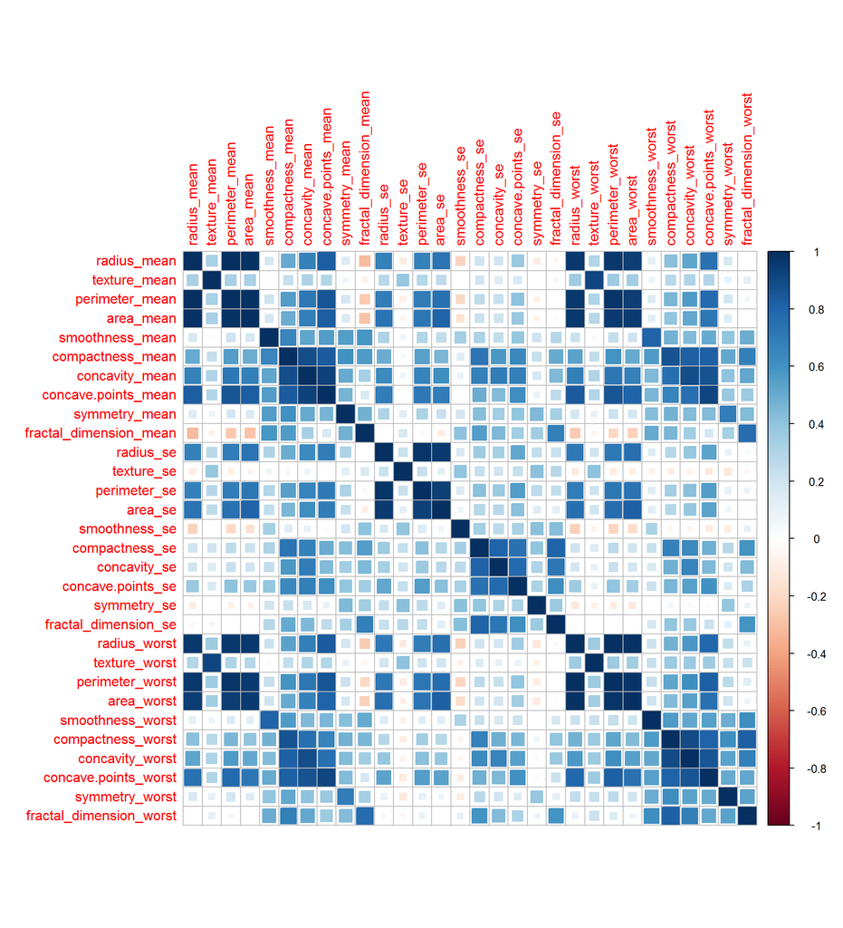

```r
library(corrplot)
corrplot(cor(bc[-1]), method = "square")
```

There are many dark blue squares mentioned these variables are high correlated.

I should remove them and refit the model

```r
library(caret)
highcor <- findCorrelation(cor(training[,-1]),cutoff = 0.6)

training.1 <- training[,-c(highcor + 1)]
test.1 <- test[, -c(highcor + 1)]
```

Refit logistic regression

```r
fit.logit.1 <- glm(diagnosis~., data = training.1, family = "binomial")
summary(fit.logit.1)
```

```
##
## Call:
## glm(formula = diagnosis ~ ., family = "binomial", data = training.1)
##
## Deviance Residuals:
##     Min       1Q   Median       3Q      Max
## -1.7128  -0.0992  -0.0097   0.0027   3.9687
##
## Coefficients:
##                        Estimate Std. Error z value Pr(>|z|)
## (Intercept)          -4.521e+01  7.096e+00  -6.372 1.86e-10 ***
## texture_mean          3.229e-01  9.485e-02   3.404 0.000664 ***
## area_mean             2.300e-02  3.693e-03   6.227 4.75e-10 ***
## texture_se            2.022e+00  8.335e-01   2.427 0.015243 *
## smoothness_se        -3.638e+02  2.818e+02  -1.291 0.196655
## symmetry_se           1.633e+01  7.879e+01   0.207 0.835759
## fractal_dimension_se -3.184e+02  2.633e+02  -1.209 0.226661
## smoothness_worst      1.442e+02  3.522e+01   4.095 4.22e-05 ***
## symmetry_worst        1.805e+01  1.086e+01   1.661 0.096632 .
## ---
## Signif. codes:  0 '***' 0.001 '**' 0.01 '*' 0.05 '.' 0.1 ' ' 1
##
## (Dispersion parameter for binomial family taken to be 1)
##
##     Null deviance: 524.251  on 397  degrees of freedom
## Residual deviance:  81.837  on 389  degrees of freedom
## AIC: 99.837
##
## Number of Fisher Scoring iterations: 9
```

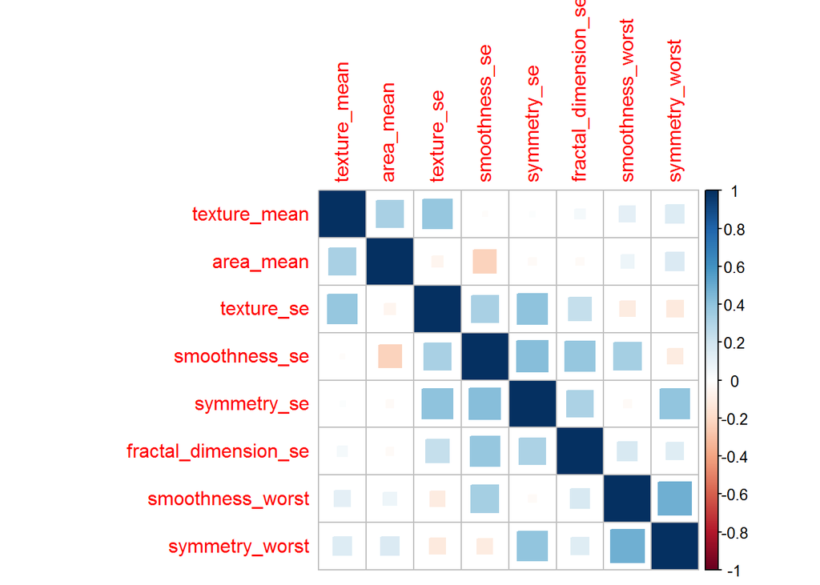

```r
corrplot(cor(training.1[-1]), method = "square")
```

We may find this model looks better

Let’s prediction by using new logistic regression

```r
pre2 <- predict(fit.logit.1, test.1, type = "response")

# set threshold = 0.3
pred.logit.1 <- ifelse(pre2 < 0.3, "B", "M")
table(test.1$diagnosis, pred.logit.1)
```

```
##    pred.logit.1
##       B   M
##   B 100   6
##   M   2  63
```

```r
1 - mean(test.1$diagnosis != pred.logit.1)
```

```
## [1] 0.9532164
```

The prediction accuracy is 95.322%

# V. Prediction Models & Machine Learning Algorithms

## 5.1. k-Nearest Neighbour Classification

### 5.1.1 Split the data and label (diagnosis)

```r
set.seed(6)
train_label <- training[,1]
train_data <- training[, 2:31]

test_label <- test[,1]
test_data <- test[, 2:31]
```

### 5.1.2 Find optimal k-value of KNN

```r
# find the optimal k
k = 0
g = 1
ii = 0
for (i in 1:20) {
  pred.knn = knn(train_data, test_data, train_label, k = i)
  k = mean(pred.knn != test_label)
  if (k < g){
    g = k
    ii = i
  }
}
pred.knn <- knn(train_data, test_data, train_label, k = ii)

ii # means k value
```

```
## [1] 4
```

```r
(tab = table(pred.knn, test_label))
```

```
##         test_label
## pred.knn   B   M
##        B 105   6
##        M   1  59
```

```r
1-g # prediction accuracy
```

```
## [1] 0.9649123
```

Prediction accuracy of KNN is 96.491%

## 5.2. k-Fold Cross Validation

For k = 10

```r
bc1 <- bc

bc1$diagnosis <- ifelse(bc1$diagnosis == "B", 1, 0)

glm.fit <- glm(diagnosis~., data = bc1)

cv.error.10 <- cv.glm(bc1, glm.fit, K = 10)$delta[1]

1 - cv.error.10
```

```
## [1] 0.9369578
```

## 5.3. Trees

### 5.3.1 Build a plot a rpart tree

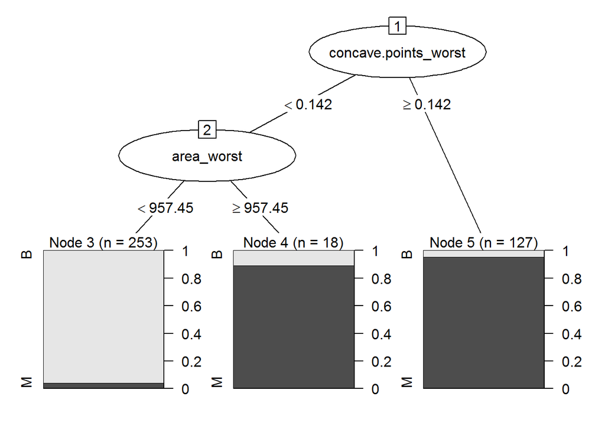

```r
cfit <- rpart(diagnosis~., data = training)
plot(as.party(cfit))
```

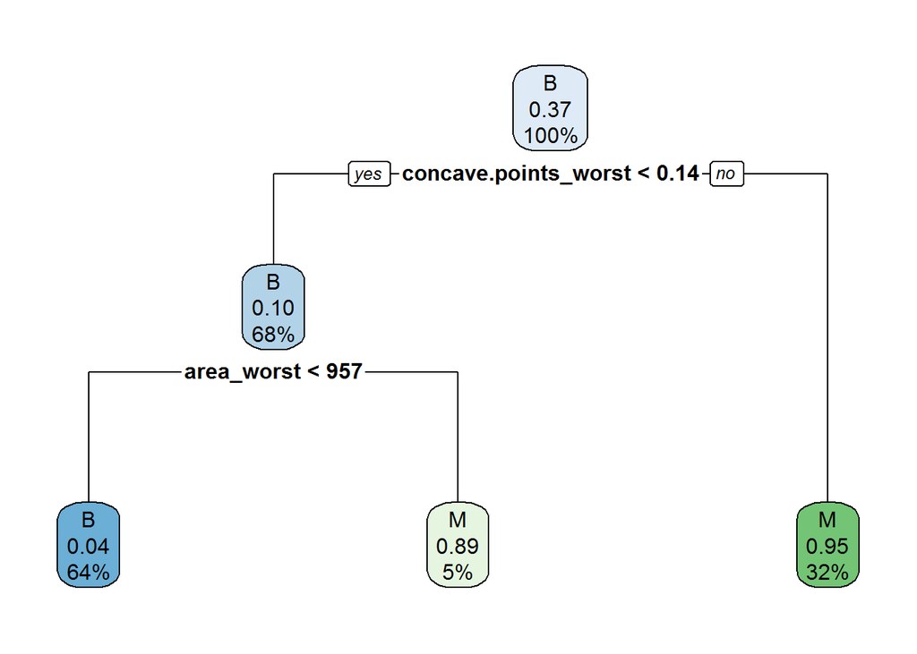

```r
rpart.plot(cfit)
```

### 5.3.2 Make prediction

Base on the ouput we don’t need to prune this tree.

Hence I directly make the prediction of classification

```r
set.seed(69)
pred.cfit<- predict(cfit, test, type = "class")

table(test_label, pred.cfit)
```

```
##           pred.cfit
## test_label  B  M
##          B 99  7
##          M  3 62
```

```r
# get accuracy
1 - mean(pred.cfit != test_label)
```

```
## [1] 0.9415205
```

The accuray of classification tree is 94.152%

## 5.4. Randomforest

### 5.4.1 Prediction Model

Randomforest with 1000 trees

```r
set.seed(6)

rf <- randomForest(diagnosis~., data = training, ntree = 1000)
rf
```

```
##
## Call:
##  randomForest(formula = diagnosis ~ ., data = training, ntree = 1000)
##                Type of random forest: classification
##                      Number of trees: 1000
## No. of variables tried at each split: 5
##
##         OOB estimate of  error rate: 4.02%
## Confusion matrix:
##     B   M class.error
## B 244   7  0.02788845
## M   9 138  0.06122449
```

```r
# make prediction
pred.rf <- predict(rf, test)

# get accuracy
1 - mean(pred.rf != test$diagnosis)
```

```
## [1] 0.9766082
```

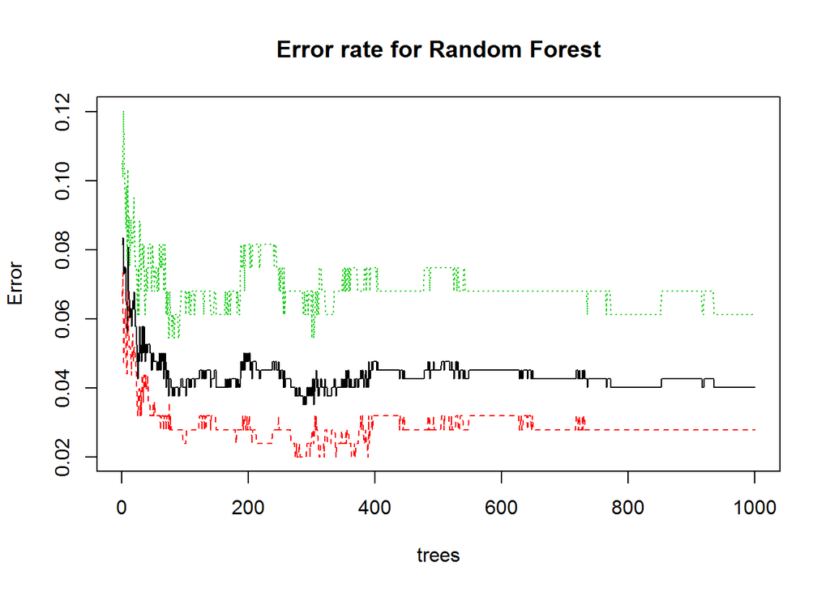

```r
plot(rf, main = "Error rate for Random Forest")
```

From the line Error rate graph, “1000 trees” is good to use.

The prediction accuracy of randomforest is 97.661%

### 5.4.2 Importance Visualization

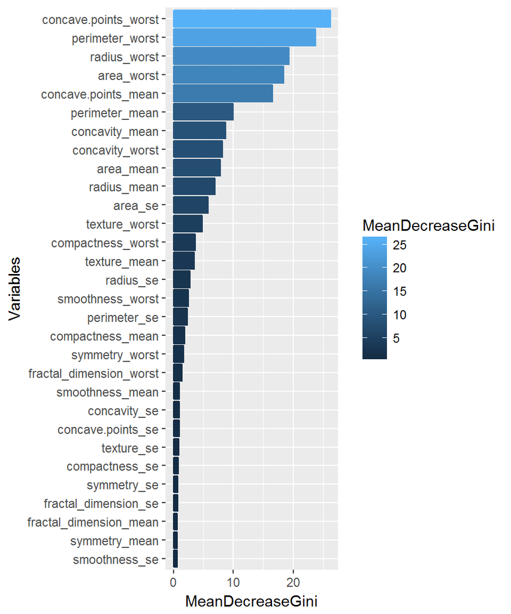

```r
importance <- data.frame(importance(rf))

ggplot(importance, aes(x = reorder(rownames(importance), MeanDecreaseGini), y = MeanDecreaseGini)) +
  geom_bar(stat = "identity" , aes(color = MeanDecreaseGini, fill = MeanDecreaseGini)) +
  coord_flip() +
  labs(x= "Variables")
```

From the Importance histogram, “concave.points_worst”, “perimeter_worst”, “radium_worst”, “area_worst” and “concave.points_mean” are the 5 most important variables.

## 5.5. Boosting

```r
set.seed(6)
training.2 <- bc1[index, ]
test.2 <- bc1[-index, ]
boost <- gbm(diagnosis~., data = training.2, distribution = "bernoulli", n.trees = 1000,
               interaction.depth = 1, shrinkage = 0.001)

pred.boost <- predict(boost, test.2, n.trees = 1000, type = "response")

# get MSE
mean((pred.boost - test.2$diagnosis)^2)
```

```
## [1] 0.07286816
```

```r
# get prediction accuracy
pred.boost <- ifelse(pred.boost >0.5, "B", "M")
1 - mean(pred.boost != test$diagnosis)
```

```
## [1] 0.9415205
```

The prediction of Boosting is 94.152%

# Conclusion

After making prediction of 6 ML & Classification methods.

We can make a plot to compare them directly.

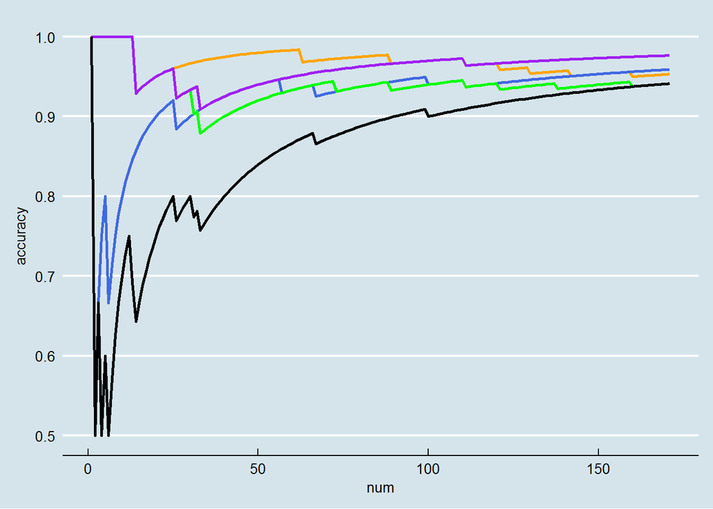

```r
library(ggthemes)

## accuracy plot for logistic regression
s <- matrix(0, nrow = length(test_label), ncol = 2)
s[,1] <- 1:length(test_label)
s[,2] <- ifelse(test_label == pred.logit.1, 1, 0)
for (i in 2:length(test_label)){
  s[i,2] = s[i-1,2] + s[i,2]
}
s[,2] = s[,2]/s[,1]
s.1 <- data.frame(s)
colnames(s.1) <- c("num", "accuracy")
g1 <- ggplot(s.1) + geom_path(aes(x = num, y = accuracy), color = "orange", size = 1)

## accuracy plot for KNN
s <- matrix(0, nrow = length(test_label), ncol = 2)
s[,1] <- 1:length(test_label)
s[,2] <- ifelse(test_label == pred.knn, 1, 0)
for (i in 2:length(test_label)){
  s[i,2] = s[i-1,2] + s[i,2]
}
s[,2] = s[,2]/s[,1]
s.2 <- data.frame(s)
colnames(s.2) <- c("num", "accuracy")
g2 <- g1 + geom_path(data = s.2, aes(x = num, y = accuracy), color = "royalblue", size = 1)

## accuracy plot for TREE
s <- matrix(0, nrow = length(test_label), ncol = 2)
s[,1] <- 1:length(test_label)
s[,2] <- ifelse(test_label == pred.cfit, 1, 0)
for (i in 2:length(test_label)){
  s[i,2] = s[i-1,2] + s[i,2]
}
s[,2] = s[,2]/s[,1]
s.3 <- data.frame(s)
colnames(s.3) <- c("num", "accuracy")
g3 <- g2 + geom_path(data = s.3, aes(x = num, y = accuracy), color = "green", size = 1)


# accuracy plot for Random Forest
s <- matrix(0, nrow = length(test_label), ncol = 2)
s[,1] <- 1:length(test_label)
s[,2] <- ifelse(test_label == pred.rf, 1, 0)
for (i in 2:length(test_label)){
  s[i,2] = s[i-1,2] + s[i,2]
}
s[,2] = s[,2]/s[,1]
s.4 <- data.frame(s)
colnames(s.4) <- c("num", "accuracy")
g4 <- g3 + geom_path(data = s.4, aes(x = num, y = accuracy), color = "purple", size = 1)

## accuract plot for Boosting
s <- matrix(0, nrow = length(test_label), ncol = 2)
s[,1] <- 1:length(test_label)
s[,2] <- ifelse(test_label == pred.boost, 1, 0)
for (i in 2:length(test_label)){
  s[i,2] = s[i-1,2] + s[i,2]
}
s[,2] = s[,2]/s[,1]
s.5 <- data.frame(s)
colnames(s.5) <- c("num", "accuracy")
g5 <- g4 + geom_path(data = s.5, aes(x = num, y = accuracy), color = "black", size = 1) + theme_economist() + scale_colour_economist()

g5
```

Base on the final accuracy plot, we can find accuracy ranking of this models in training Breast Cancer data,

- 1. Random Forest (97.661%)
- 2. k-Nearest Neighbor (96.491%)
- 3. Logistic Regression (95.322%)
- 4. Trees (94.152%)
- 5. Boosting (94.152%)
- 6. 10-fold Cross Validation (93.696%)

# Improvement

- Feature selection is required for any data analysis work and there are many methods we can use e.g. AIC, BIC, “Pearson” Correlation Coefficient;
- It’s better to read related “dictionary” of your data, try to understand variables and make a comparably good formula by yourself.
- Visualization is pretty important to do data analysis.